# Topic Modelling Homework

Dmitri Bobrikov

11 Декабрь, 2022

## Data Preparation

### Data Description

*What is the data?*

For this homework project I took tweets by hashtag **#blm** (black lives matter) about people of movement that support ethnic minorities including afro-american people against racism mainly in the USA. Thus, each document in the whole corpus is a tweet that was found by this hashtag on the 1st and 2nd of December.

*Where is the data from?*

All tweets were obtained thanks to [Vicinitas](https://www.vicinitas.io/free-tools/download-search-tweets) that allows to download tweets by hashtag. It requires user’s login and password to download necessary data but I do not use twitter a lot these days, so I wasn’t afraid of possible negative consequences of such a behaviour.

*What are the useful columns?*

There are plenty of different columns in the dataset that you get from this website but the most useful, from my point of view, are columns **Language** and **Tweet Type**. We can filter our tweets due to them and leave tweets only in English and those which are not retweets (as they repeat the original tweet so there may be cases of duplicates).

### Filtering Data

Before we start data preprocessing let’s filter out our data and add document id that will help us later.

```r
library(readr)
library(dplyr)
library(stringr)
library(stringi)
data = read.csv("~/rrrr/cmat/hw2/vicinitas_blm.csv", header=T, sep=";")

data = data %>% mutate(OrigTweet = Text) %>% filter(Language == "en") %>% filter(Tweet.Type != "Retweet") %>%  select(OrigTweet)
data = data %>% mutate(doc_id = row_number())

head(data, 5)
```

|  | OrigTweet | doc_id |
| --- | --- | --- |
| 1 | @CTVToronto If he was #BLM, Blackface Trudeau would make sure all his guns and drugs were returned to him along with an apology. | 1 |
| 2 | @ThisIsKyleR There is a huge group in the United States as we speak who are hurting. When they called out for help, acknowledgment and understanding they, and their allies were dismissed, belittled, m… | 2 |
| 3 | @AVintenAuthor I'm guessing Alice was off on maternity leave during the 2011 riots. The threat then to police lives was palpable to anyone on the front line. Had Alice experienced it she wouldn't be m… | 3 |
| 4 | Mr.Musk suspends fuckin rapper Ye account RT 2do where's fuckin #BLM's now????\n@Carolyn143413 @blu3eyedbabii45 @Teebaby19588204 @45anm1 @mgarcia1701temp @Bellamari8mazz @angie_anson @Dora77562818 @Tw… | 4 |
| 5 | @KDKA And the #CovidVaccine is a good way to be #HeartHealthy and prevent the risk of stroke.\n\nThat's why Doctor #Fauci says everyone needs the #Bivalenr #Booster as soon as possible.\n\n#healthy #H… | 5 |

### Stop Words

As for now, let’s create our own list of stop words including #blm as it does not bring any sense in our work as we have already obtained the data based on this hashtag.

```r
library(stopwords)
stop_words = stopwords("en")
modified_stop_words = append(stop_words, c('#blm', 'co', 'https', 't', 'amp'))
modified_stop_words[176]
```

```
## [1] "#blm"
```

Everything works and #blm in the stop words list.

### Preprocessing

Now we proceed to the tokenization, lemmatization, deleting stop words, numbers and usernames that start with “@”.

```r
library(textstem)
library(tidytext)


data_lemmas = data %>%
    unnest_tokens(word, OrigTweet, token="tweets") %>%
    mutate(lem = lemmatize_words(word)) %>%
    filter(!str_detect(lem, "@\\w+")) %>%
    filter(! lem %in% modified_stop_words) %>%
    filter(! str_detect(lem, "[0-9]+"))

head(data_lemmas, 20)
```

|  | doc_id | word | lem |
| --- | --- | --- | --- |
| 1 | 1 | blackface | blackface |
| 2 | 1 | trudeau | trudeau |
| 3 | 1 | make | make |
| 4 | 1 | sure | sure |
| 5 | 1 | guns | gun |
| 6 | 1 | drugs | drug |
| 7 | 1 | returned | return |
| 8 | 1 | along | along |
| 9 | 1 | apology | apology |
| 10 | 2 | huge | huge |

[output cut: 10 more lines]

### Some Statistics

Corpus size:

```r
data_lemmas  %>% nrow
```

```
## [1] 8755
```

We have 8755 lemmatized words in our corpus.

Vocabulary size:

```r
data_lemmas %>% distinct(lem) %>% nrow
```

```
## [1] 3302
```

We have 3302 distinct lemmatized words in our corpus.

Distribution of tweets’ length in tokens:

```r
data_temp = data %>% mutate(len = lengths(gregexpr("\\W+", OrigTweet)))
summary(data_temp$len)
```

```
##    Min. 1st Qu.  Median    Mean 3rd Qu.    Max.
##    3.00   18.00   29.00   29.63   41.00   64.00
```

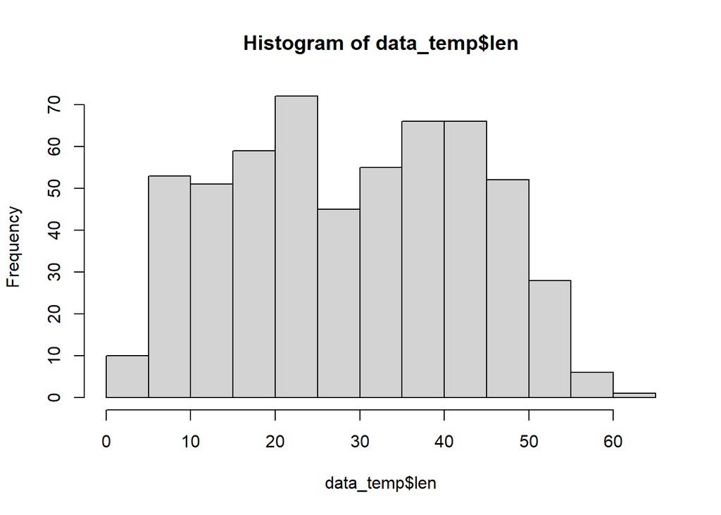

```r
hist(data_temp$len)
```

We have minimum 3 tokens in tweet, 29 tokens in median, almost 30 tokens in mean and maximum is 64 tokens

## LDA

### LDA: data preparation

Before we start creating the model itself we need to make a lemmatized version of our initial tweets.

```r
data_clean = data_lemmas %>%
  group_by(doc_id) %>%
  summarize(text = paste(lem, collapse = ' '))

data_clean = merge(x = data_clean, y = data, by = "doc_id", all.x = TRUE)
head(data_clean)
```

|  | doc_id | text | OrigTweet |
| --- | --- | --- | --- |
| 1 | 1 | blackface trudeau make sure gun drug return along apology | @CTVToronto If he was #BLM, Blackface Trudeau would make sure all his guns and drugs were returned to him along with an apology. |
| 2 | 2 | huge group unite state speak hurt call help acknowledgment understand ally dismiss belittle mock meet violence perhaps educate | @ThisIsKyleR There is a huge group in the United States as we speak who are hurting. When they called out for help, acknowledgment and understanding they, and their allies were dismissed, belittled, m… |
| 3 | 3 | im guess alice maternity leave riot threat police life palpable anyone front line alice experience wouldnt make stupid comment blm much example constant ttl pos face | @AVintenAuthor I'm guessing Alice was off on maternity leave during the 2011 riots. The threat then to police lives was palpable to anyone on the front line. Had Alice experienced it she wouldn't be m… |
| 4 | 4 | mrmusk suspend fuckin rapper ye account rt fuckin #blms now https://t.co/xnacxtcrvk | Mr.Musk suspends fuckin rapper Ye account RT 2do where's fuckin #BLM's now????\n@Carolyn143413 @blu3eyedbabii45 @Teebaby19588204 @45anm1 @mgarcia1701temp @Bellamari8mazz @angie_anson @Dora77562818 @Tw… |
| 5 | 5 | #covidvaccine good way #hearthealthy prevent risk stroke thats doctor #fauci say everyone need #bivalenr #booster soon possible #healthy #healthynation #science #scienceforukraine #spotifywrapped #vac… | @KDKA And the #CovidVaccine is a good way to be #HeartHealthy and prevent the risk of stroke.\n\nThat's why Doctor #Fauci says everyone needs the #Bivalenr #Booster as soon as possible.\n\n#healthy #H… |
| 6 | 6 | need go fake charity antiroyal antiwhite racist antibritish fund marxist #ngozifulaniisadisgrace #ngozifulaniisaliar #ngozifulaniisaracebaiter #ladysusanhussey #ladyhussey | @NgoziFulani needs to go. \n@Sistah_Space is a FAKE CHARITY, is an anti-Royal, Anti-White (Racist), Anti-British and funded by the #BLM! Marxists OUT OUT OUT! ????????\n#NgoziFulaniIsADisgrace \n#Ngoz… |

Well, it looks well, so we can proceed to the next step

### LDA: model setup

Before we start model setup we need to set options for java usage

```r
library(rJava)
library(mallet)
options(java.parameters = "-Xmx1g")
```

Then we need to save our modified list of stop words to use it later.

```r
#write_lines(modified_stop_words, "stopwords_blm.txt")
```

Mallet has to process documents texts to tokenize texts and to collect usage statistics

```r
mallet.instances = mallet.import(id.array=as.character(data_clean$doc_id),
                                  text.array=data_clean$text,
                                  stoplist="stopwords_blm.txt")
```

Now we tune our model with 10 topics, fixing seed for reproducibility and optimizing hyperparameters

```r
topic.model = MalletLDA(num.topics=10)
topic.model$setRandomSeed(42L)
topic.model$loadDocuments(mallet.instances)
topic.model$setAlphaOptimization(20, 50)
```

So, now we can see word frequencies list

```r
vocabulary = topic.model$getVocabulary()
word.freqs = mallet.word.freqs(topic.model)
word.freqs %>% arrange(desc(doc.freq)) %>% head(10)
```

|  | word | word.freq | doc.freq |
| --- | --- | --- | --- |
| 1 | people | 80 | 66 |
| 2 | black | 74 | 62 |
| 3 | blacklivesmatter | 59 | 59 |
| 4 | racist | 46 | 40 |
| 5 | much | 43 | 37 |
| 6 | police | 34 | 34 |
| 7 | maga | 36 | 34 |
| 8 | truth | 34 | 34 |
| 9 | us | 34 | 33 |
| 10 | like | 37 | 33 |

We can see that most frequent words are *people*, *black* and *racist* that tells us about the general discourse of tweets with #blm. It all seems fine, thus we can go the the next step

### LDA: training a model

Let’s set the number of iterations for training.

```r
topic.model$train(500)
```

And let’s select the best topic for each token in 10 iterations.

```r
topic.model$maximize(10)
```

### LDA: results

Doc-topics table:

```r
doc.topics = mallet.doc.topics(topic.model, smoothed=TRUE, normalized=TRUE)
head(doc.topics)
```

```
##             [,1]        [,2]        [,3]         [,4]        [,5]        [,6]
## [1,] 0.003112835 0.959011199 0.003561437 0.0016272539 0.004777206 0.013040044
## [2,] 0.001598735 0.438498095 0.001829135 0.0008357491 0.002453548 0.006697298
## [3,] 0.001116155 0.834377038 0.001277008 0.0005834769 0.001712940 0.155601506
## [4,] 0.002571617 0.009872973 0.002942223 0.0013443292 0.960211408 0.010772819
## [5,] 0.001159920 0.122085979 0.001327081 0.0006063555 0.001780106 0.004859047
## [6,] 0.001908106 0.007325617 0.002183091 0.0009974747 0.002928333 0.975542343
##             [,7]        [,8]         [,9]       [,10]
## [1,] 0.004515712 0.003189400 0.0022527371 0.004912178
## [2,] 0.542769517 0.001638059 0.0011569940 0.002522869
## [3,] 0.001619178 0.001143608 0.0008077535 0.001761337
## [4,] 0.003730581 0.002634870 0.0018610620 0.004058116
## [5,] 0.001682667 0.001188450 0.0008394263 0.864470968
## [6,] 0.002768043 0.001955039 0.0013808837 0.003011069
```

Each row represent the proportions of topics in this document.

Word-topics table:

```r
topic.words = mallet.topic.words(topic.model, smoothed=TRUE, normalized=TRUE)
```

(It is a huge table so we will not show it in the output otherwise eyes will be full of tears…)

Topic labels with 10 top words:

```r
topic.labels = mallet.topic.labels(topic.model, topic.words, 10)
topic.labels
```

```
##  [1] "lady hussey royal fulani family palace shes meghan ngozi prince"
##  [2] "people like get just life much support help black im"
##  [3] "blacklivesmatter defundthepolice watch abolishthepolice police portland muslim protester slave portlandoregon"
##  [4] "hurt cut georgia atlanta georgiavoters socialsecurity maga votewarnockga voteredtohurtyourself voterepublican"
##  [5] "trump biden racism maga truth kanye ukraine whitesupremacy know humanrights"
##  [6] "black people white racist fund much charity hate one man"
##  [7] "us black right park rosa inspire good know today day"
##  [8] "equality justice us blacklivesmatter prison boomer truth diversity ados artist"
##  [9] "subscribe bible iuic come miami africanamerican south truth love stay"
## [10] "see lgbtq time can fifaworldcup live now say thank believe"
```

## Interpretation

### Topics interpretation

Now let’s interpret each topic top words separately First topic:

```r
topic.labels[1]
```

```
## [1] "lady hussey royal fulani family palace shes meghan ngozi prince"
```

Surprisingly, we can see that this topic is somehow connected to British royal family (as there is mentioning of Meghan and the only Meghan from any royal family is Meghan Markle)

Second topic:

```r
topic.labels[2]
```

```
## [1] "people like get just life much support help black im"
```

These top words are rather broad in terms of meaningfulness but we may assume that these words may reflect the idea of equality of people and value of each person’s life

Third topic:

```r
topic.labels[3]
```

```
## [1] "blacklivesmatter defundthepolice watch abolishthepolice police portland muslim protester slave portlandoregon"
```

This topic is more interpretable than the previous one because here we can track the part of the movement BLM that was against police broad rights in terms of people arresting and killing them under any minor circumstances. Moreover, we can see that Portland is mentioned here. Probably, there is a huge problem with police power in this particular city.

Fourth topic:

```r
topic.labels[4]
```

```
## [1] "hurt cut georgia atlanta georgiavoters socialsecurity maga votewarnockga voteredtohurtyourself voterepublican"
```

These top words seem to have connection between the place where the whole movement has appeared (it appeared in Atlanta, Georgia as there was a shocking case of police abuse of authority) and the recent election campaign in the USA where Republicans have been participating in it.

Fifth topic:

```r
topic.labels[5]
```

```
## [1] "trump biden racism maga truth kanye ukraine whitesupremacy know humanrights"
```

These words may be grouped all together to the racist problem in the USA in particular because such people as Trump, Biden and Kanye are mentioned here (Kanye and Trump are famous for their raсist speaches and statements especially in the twitter) as well as word racism and white supremacy itself.

Sixth topic:

```r
topic.labels[6]
```

```
## [1] "black people white racist fund much charity hate one man"
```

These top words as in the previous topic contain word racist but in this case there are also words fund and charity. That may mean that these topic words reflect the charity part of the movement BLM that take care of people who are the victims of racism/police abuse of authority based on race and so on.

Seventh topic:

```r
topic.labels[7]
```

```
## [1] "us black right park rosa inspire good know today day"
```

Unfortunately, top words in this topic are too broad so we can not define some one particular topic.

Eighth topic:

```r
topic.labels[8]
```

```
## [1] "equality justice us blacklivesmatter prison boomer truth diversity ados artist"
```

These top words are much better than in the previous case. They reflect the idea of equality and justice that must be provided by the state and the people to ensure the equal rights of all diverse people.

Ninth topic:

```r
topic.labels[9]
```

```
## [1] "subscribe bible iuic come miami africanamerican south truth love stay"
```

Here we can group these words by the theme of Christianity in the south of the USA. We assume so because there are words such as bible, love and truth (that all may be referred to the religion as the first one word is literally the holy book of Christianity and the second and the third words are the basic principles in some sense of this religion), south and Miami (that is also located in the south of the USA)

Tenth topic:

```r
topic.labels[10]
```

```
## [1] "see lgbtq time can fifaworldcup live now say thank believe"
```

These words seem a little far from the general discourse of the BLM movement because there is no mentioning of any crucial word of this movement (such as people, racism/racist, black and so on). We may assume that in this case the hashtag was used for awareness raising as there was indeed a problem with LGBTQ rights during the FIFA World Cup (the championship is hold in the Doha, Qatar where it is not legal to be gay).

Also, we have made the short names for the topics: 1 - “British Royal Family” 2 - “Broad2” 3 - “Police Abuse of Authority” 4 - “Atlanta & Election” 5 - “Racists” 6 - “Charity” 7 - “Broad7”, 8 - “Equality” 9 - “Christianity & South” 10 - “LGBTQ & FIFA”

### Visualisation

We will create cluster dendrogram to see similarity by the set of words in the topics. Before we start we will also create the short labels for the topics.

```r
topic.labels.short = c("British Royal Family", "Broad2", "Police Abuse of Authority", "Atlanta & Election", "Racists", "Charity", "Broad7", "Equality", "Christianity & South", "LGBTQ & FIFA")
```

Now the cluster dendrogram itself:

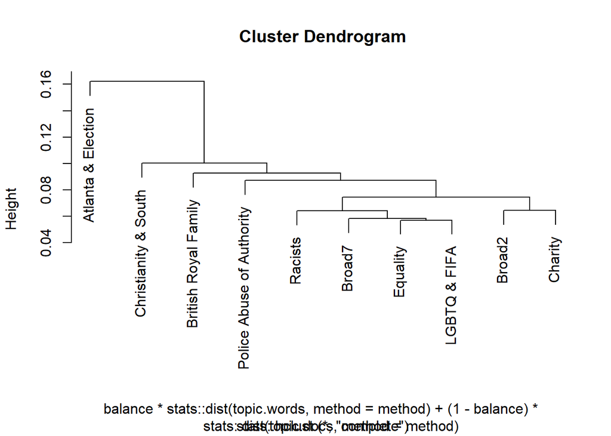

```r
plot(mallet.topic.hclust(doc.topics, topic.words, 1), labels=topic.labels.short)
```

We can see that the least similar topic in terms of words is the topic that we have labeled as “Atlanta & Election”, whereas other topics are more similar in terms of words usage. “Charity” and “Broad2” are especially similar; “Racists”, “Broad7”, “Equality” and “LGBTQ & FIFA” are also similar and can be grouped to one cluster. We can assume that “Racists”, “Broad7”, “Equality” and “LGBTQ & FIFA” are so similar between each other in terms of words because they all are somehow tell about the rights of diverse people.

### Topic proportions in all the collection

Firstly, let’s see the raw numbers

```r
colSums(doc.topics)
```

```
##  [1]  33.25313 118.07082  46.94481  26.01692  53.07492 125.92154  45.17996
##  [8]  34.15851  27.89202  52.48736
```

Secondly, let’s binarize data with threshold that is equal to 0.04. We assume that topic is present in the document, if its proportion > 0.04, otherwise, it is not presented in doc

```r
doc.topics.bin = ifelse(doc.topics > 0.04, 1, 0)
colSums(doc.topics.bin)
```

```
##  [1]  45 217  57  27  77 214  61  42  34  71
```

Now we have some more meaningful numbers. Let’s visualize them

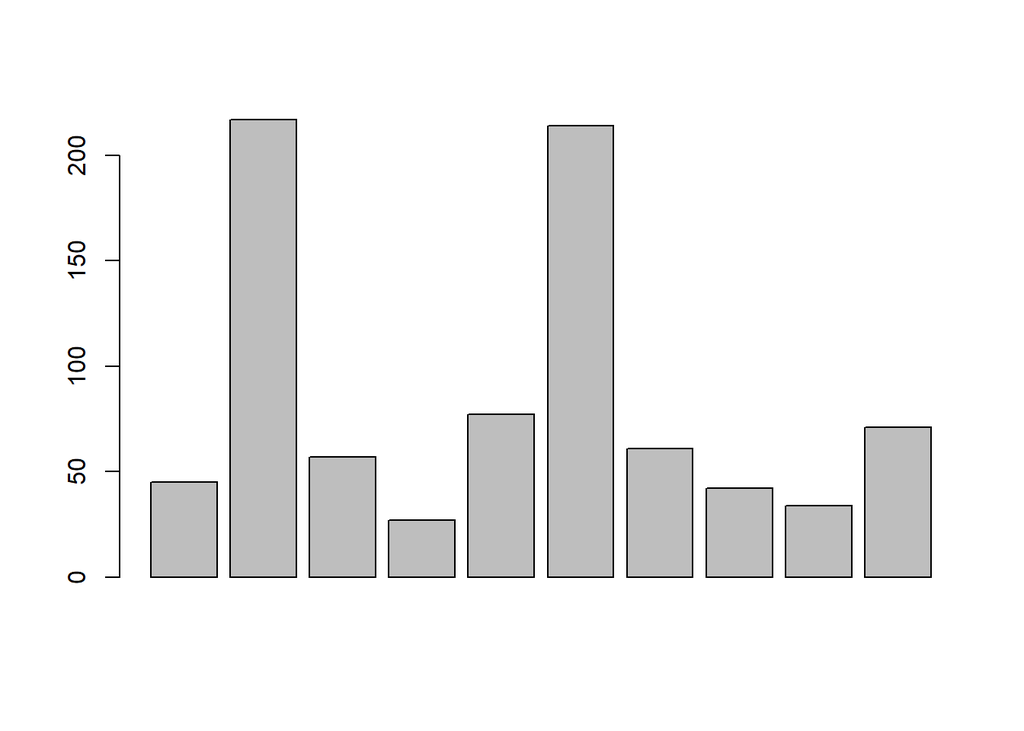

```r
colsum = colSums(doc.topics.bin)
barplot(colsum)
```

We can see that the most frequent topics are the second and the sixth ones. While the second one is “Broad2” and does not mean a lot to us, the sixth topic that is called “Charity” is much more important for us as it may mean that nowadays people care more about charity for people who became victims of racism.